# salmon outmigrant phenology

### priors

Initially, I accepted the default priors that `brms` employs. These weren’t bad – ‘flat’ for all except for the `intercepts` and for `sigma` where it uses `student_t`, but the tuning done for `bmod5` really improved the model outcome.

```
                   prior     class                             coef group resp
                  (flat)         b
                  (flat)         b                            mowyt
                  (flat)         b            mowyt:wy_meanCentered
                  (flat)         b                 percentileday_50
                  (flat)         b                 percentileday_90
                  (flat)         b       regionLowerSacramentoRiver
                  (flat)         b                 regionNorthDelta
                  (flat)         b                 regionSouthDelta
                  (flat)         b                  wy_meanCentered
                  (flat)         b wy_meanCentered:percentileday_50
                  (flat)         b wy_meanCentered:percentileday_90
 student_t(3, 147, 29.7) Intercept
   student_t(3, 0, 29.7)     sigma
            dirichlet(1)      simo           mowyt:wy_meanCentered1
            dirichlet(1)      simo                           mowyt1
 dpar nlpar lb ub tag       source
                           default
                      (vectorized)
                      (vectorized)
                      (vectorized)
                      (vectorized)
                      (vectorized)
                      (vectorized)
                      (vectorized)
                      (vectorized)
                      (vectorized)
                      (vectorized)
                           default
             0             default
                           default
                           default
```

```
                   prior     class                             coef group resp
                  (flat)         b
                  (flat)         b                            mowyt
                  (flat)         b            mowyt:wy_meanCentered
                  (flat)         b                 percentileday_50
                  (flat)         b                 percentileday_90
                  (flat)         b       regionLowerSacramentoRiver
                  (flat)         b                 regionNorthDelta
                  (flat)         b                 regionSouthDelta
                  (flat)         b                  wy_meanCentered
                  (flat)         b wy_meanCentered:percentileday_50
                  (flat)         b wy_meanCentered:percentileday_90
 student_t(3, 147, 29.7) Intercept
           gamma(2, 0.1)        nu
   student_t(3, 0, 29.7)     sigma
            dirichlet(1)      simo           mowyt:wy_meanCentered1
            dirichlet(1)      simo                           mowyt1
 dpar nlpar lb ub tag       source
                           default
                      (vectorized)
                      (vectorized)
                      (vectorized)
                      (vectorized)
                      (vectorized)
                      (vectorized)
                      (vectorized)
                      (vectorized)
                      (vectorized)
                      (vectorized)
                           default
             1             default
             0             default
                           default
                           default
```

```
                     prior     class                       coef group resp dpar
                    (flat)         b
                    (flat)         b                     ff_wyd
                    (flat)         b    ff_wyd:percentileday_50
                    (flat)         b    ff_wyd:percentileday_90
                    (flat)         b           percentileday_50
                    (flat)         b           percentileday_90
                    (flat)         b regionLowerSacramentoRiver
                    (flat)         b           regionNorthDelta
                    (flat)         b           regionSouthDelta
                    (flat)         b            wy_meanCentered
 student_t(3, 146.5, 28.9) Intercept
             gamma(2, 0.1)        nu
     student_t(3, 0, 28.9)     sigma
 nlpar lb ub tag       source
                      default
                 (vectorized)
                 (vectorized)
                 (vectorized)
                 (vectorized)
                 (vectorized)
                 (vectorized)
                 (vectorized)
                 (vectorized)
                 (vectorized)
                      default
        1             default
        0             default
```

```
                     prior     class                       coef group resp dpar
                    (flat)         b
                    (flat)         b                     ff_wyd
                    (flat)         b    ff_wyd:percentileday_50
                    (flat)         b    ff_wyd:percentileday_90
                    (flat)         b           percentileday_50
                    (flat)         b           percentileday_90
                    (flat)         b regionLowerSacramentoRiver
                    (flat)         b           regionNorthDelta
                    (flat)         b           regionSouthDelta
                    (flat)         b            wy_meanCentered
 student_t(3, 146.5, 28.9) Intercept
             gamma(2, 0.1)        nu
     student_t(3, 0, 28.9)        sd
     student_t(3, 0, 28.9)        sd                               wy
     student_t(3, 0, 28.9)        sd                  Intercept    wy
     student_t(3, 0, 28.9)     sigma
 nlpar lb ub tag       source
                      default
                 (vectorized)
                 (vectorized)
                 (vectorized)
                 (vectorized)
                 (vectorized)
                 (vectorized)
                 (vectorized)
                 (vectorized)
                 (vectorized)
                      default
        1             default
        0             default
        0        (vectorized)
        0        (vectorized)
        0             default
```

```
           prior     class                       coef group resp dpar nlpar lb
   normal(0, 30)         b
    normal(0, 1)         b                     ff_wyd
    normal(0, 1)         b    ff_wyd:percentileday_50
    normal(0, 1)         b    ff_wyd:percentileday_90
   normal(0, 30)         b           percentileday_50
   normal(0, 30)         b           percentileday_90
   normal(0, 30)         b regionLowerSacramentoRiver
   normal(0, 30)         b           regionNorthDelta
   normal(0, 30)         b           regionSouthDelta
    normal(0, 2)         b            wy_meanCentered
 normal(150, 50) Intercept
   gamma(2, 0.1)        nu                                                   1
   normal(0, 20)        sd                                                   0
   normal(0, 20)        sd                               wy                  0
   normal(0, 20)        sd                  Intercept    wy                  0
  exponential(1)     sigma                                                   0
 ub tag       source
                user
                user
                user
                user
        (vectorized)
        (vectorized)
        (vectorized)
        (vectorized)
        (vectorized)
                user
                user
                user
                user
        (vectorized)
        (vectorized)
                user
```

## environmental predictability

to do (working with `thresholds_annual`):

- center water year (wyd) DONE
- add FF dates DONE
- add wyt?
- calculate env pred for each…region? station?? using d10, d50, d90??? DONE
- station should probably be a factor
- run analyses

```r
# find wyd when each threshold (10, 50, 90) is first crossed during Jan-Mar period
thresholds_JanMar <- daily_site %>%
  filter(wyd >= 93 & wyd <= 182) %>%
  group_by(region_label, station, wy) %>%
  arrange(wyd) %>%
  mutate(
    annual_total = sum(daily_total),
    cumul_percent = 100 * cumsum(daily_total) / annual_total
  ) %>%
  summarise(
    d10 = wyd[which(cumul_percent >= 10)[1]],
    d50 = wyd[which(cumul_percent >= 50)[1]],
    d90 = wyd[which(cumul_percent >= 90)[1]],
    .groups = "drop"
  )

# find wyd when each threshold (10, 50, 90) is first crossed over entire WY

thresholds_annual <-
  daily_site %>%
  group_by(region_label, station, wy) %>%
  arrange(wyd) %>%
  mutate(
    annual_total = sum(daily_total),
    cumul_percent = 100 * cumsum(daily_total) / annual_total
  ) %>%
  summarise(
    d10 = wyd[which(cumul_percent >= 10)[1]],
    d50 = wyd[which(cumul_percent >= 50)[1]],
    d90 = wyd[which(cumul_percent >= 90)[1]],
    .groups = "drop"
  ) %>%
  # calc accumul rate...not really a rate but time interval freq equals 0 (ie (50-10)/0 = Inf), so have to think about this
  # calc mean-centered water year for better model performance
  mutate(accumul_rate = d50 - d10,
         wy_meanCentered = wy - mean(wy)) %>%
  left_join(storms,
            by = "wy",
            keep = FALSE) %>%
  select(-c(id, date)) %>%
  filter(!is.na(ff_wyd)) %>%
  relocate(ff_wyd, .after = "wy_meanCentered")

# dev matrix for calc Colwell's env pred
# convert wyd to week-of-water-year
colwell_data <- daily_site %>%
  filter(wy >= 1998) %>%
  group_by(region_label, station, wy) %>%
  arrange(wyd) %>%
  mutate(
    annual_total = sum(daily_total),
    cumul_percent = 100 * cumsum(daily_total) / annual_total
  ) %>%
  summarise(
    d10 = wyd[which(cumul_percent >= 10)[1]],
    d50 = wyd[which(cumul_percent >= 50)[1]],
    d90 = wyd[which(cumul_percent >= 90)[1]],
    .groups = "drop"
  ) %>%
  # median crossing date across stations within region-year
  group_by(region_label, wy) %>%
  summarise(across(c(d10, d50, d90), \(x) median(x, na.rm = TRUE)),
            .groups = "drop") %>%
  # convert wyd to water year month (1=Oct, 2=Nov, ... 12=Sep)
  mutate(across(c(d10, d50, d90),
                \(x) cut(x,
                         breaks = c(0, 31, 61, 92, 123, 151, 182, 212, 243, 273, 304, 334, 366),
                         labels = 1:12),
                .names = "{.col}_month"))

# for each region, pivot and count
colwell_matrix <- colwell_data %>%
  pivot_longer(cols = ends_with("_month"),
               names_to = "benchmark", values_to = "month") %>%
  filter(!is.na(month)) %>%
  group_by(region_label, benchmark, month) %>%
  summarise(count = n(), .groups = "drop") %>%
  # fill in zero-count months
  complete(region_label, benchmark, month = factor(1:12), fill = list(count = 0))

# calc P, M, C, Colwell's metrics for predictability, contingency and constancy
colwell_stats <- colwell_matrix %>%
  group_by(region_label) %>%
  group_modify(~ {

    # wide matrix: rows = months (1-12), cols = benchmarks (d10, d50, d90)
    mat <- .x %>%
      mutate(month = as.integer(month)) %>%
      pivot_wider(names_from = benchmark, values_from = count, values_fill = 0) %>%
      arrange(month) %>%
      select(-month) %>%
      as.matrix()

    N <- sum(mat)
    s <- ncol(mat)       # number of states = 3
    Z <- log(s)          # normalizing constant; switch to log2() if you want bits

    # cell proportions and marginals
    p_ij <- mat / N
    p_i  <- rowSums(p_ij)   # time interval marginals
    p_j  <- colSums(p_ij)   # state marginals

    # 0 * log(0) = 0 by convention
    xlogx <- function(x) ifelse(x == 0, 0, x * log(x))

    HX  <- -sum(xlogx(p_j))    # uncertainty in state
    HY  <- -sum(xlogx(p_i))    # uncertainty in time
    HXY <- -sum(xlogx(p_ij))   # joint uncertainty

    C <- 1 - HX / Z             # constancy
    M <- (HX + HY - HXY) / Z   # contingency
    P <- C + M                  # predictability

    tibble(C = round(C, 3),
           M = round(M, 3),
           P = round(P, 3))
  })

colwell_stats
```

```
# A tibble: 7 × 4
# Groups:   region_label [7]
  region_label                       C      M      P
  <fct>                          <dbl>  <dbl>  <dbl>
1 Central Delta                      0  0.286  0.286
2 Lower Sacramento River             0  0.446  0.446
3 North Delta                        0  0.522  0.522
4 Sacramento River                  NA NA     NA
5 San Francisco & San Pablo Bays    NA NA     NA
6 San Joaquin River                 NA NA     NA
7 South Delta                        0  0.038  0.038
```

```r
# why the NAs for Sac R, SF/SP bays, SJR? is this a data issue?
colwell_matrix %>%
  filter(region_label %in% c("Sacramento River",
                             "San Francisco & San Pablo Bays",
                             "San Joaquin River")) %>%
  group_by(region_label) %>%
  summarise(total_count = sum(count))
```

```
# A tibble: 3 × 2
  region_label                   total_count
  <fct>                                <int>
1 Sacramento River                         0
2 San Francisco & San Pablo Bays           0
3 San Joaquin River                        0
```

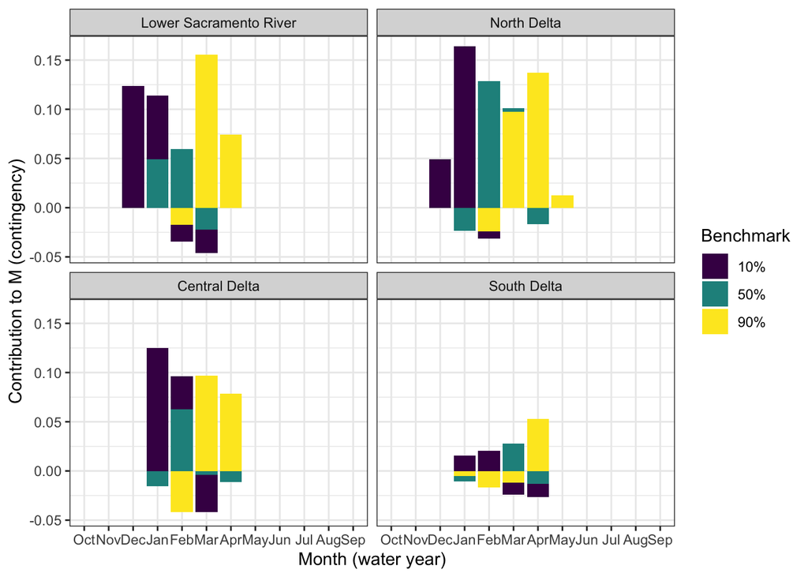

```r
# the total counts are 0...how is this possible? will have to look into this

# C=0 (constancy): no surprise that benchmarks are reached in different months
# during different years, but surely there must be some overlap and C would be low but not 0. will have to look into this too

# Which months contribute most to M (contingency)? If we can determine this, that'd tell me whether predictability is concentrated in a seasonal window or spread out across the year.
colwell_monthly <- colwell_matrix %>%
  group_by(region_label) %>%
  group_modify(~ {

    mat <- .x %>%
      mutate(month = as.integer(month)) %>%
      pivot_wider(names_from = benchmark, values_from = count, values_fill = 0) %>%
      arrange(month) %>%
      select(-month) %>%
      as.matrix()

    N <- sum(mat)
    s <- ncol(mat)
    Z <- log(s)

    p_ij <- mat / N
    p_i  <- rowSums(p_ij)
    p_j  <- colSums(p_ij)

    # each cell's contribution to M
    # M_ij = (p_ij * log(p_ij / (p_i * p_j))) / Z
    contrib <- matrix(NA, nrow = nrow(mat), ncol = ncol(mat))
    for (i in 1:nrow(mat)) {
      for (j in 1:ncol(mat)) {
        if (is.na(p_ij[i,j]) || p_ij[i,j] == 0 ||
            is.na(p_i[i])    || p_i[i] == 0    ||
            is.na(p_j[j])    || p_j[j] == 0) {
          contrib[i,j] <- 0
        } else {
          contrib[i,j] <- p_ij[i,j] * log(p_ij[i,j] / (p_i[i] * p_j[j])) / Z
        }
      }
    }

    colnames(contrib) <- colnames(mat)

    as_tibble(contrib) %>%
      mutate(month = 1:12)
  }) %>%
  pivot_longer(cols = c(d10_month, d50_month, d90_month),
               names_to = "benchmark", values_to = "M_contrib") %>%
  mutate(
    month = factor(month, levels = 1:12,
                   labels = c("Oct","Nov","Dec","Jan","Feb","Mar",
                              "Apr","May","Jun","Jul","Aug","Sep"))
  )

# plot which months contribute most to M across each region; is predictability concentrated in a narrow seasonal window or spread out across the year?
colwell_monthly %>%
  filter(!region_label %in% c("Sacramento River", "San Francisco & San Pablo Bays", "San Joaquin River")) %>%
  mutate(region_label = factor(region_label,
                               levels = c("Lower Sacramento River", "North Delta", "Central Delta", "South Delta"))) %>%
  mutate(benchmark = case_match(benchmark,
                                "d10_month" ~ "10%",
                                "d50_month" ~ "50%",
                                "d90_month" ~ "90%",
                                # keeps unmatched values unchanged (shouldn't be needed)
                                .default = benchmark)) %>%
  ggplot(aes(x = month, y = M_contrib, fill = benchmark)) +
  geom_col() +
  facet_wrap(~ region_label) +
  scale_fill_viridis_d() +
  theme_bw() +
  labs(x = "Month (water year)",
       y = "Contribution to M (contingency)",
       fill = "Benchmark")
```

```r
ggsave(here("salmon/plots/monthly_contrib_predictability.png"))
```

## next steps

Can I look at this for WR only? Include other LAD-based run designations?

Try the mixed effects modeling approach that Jereme recommended.

What happens if I limit the data to genetically-typed salmon but with (necessarily) reduced time series?

Need to consider finer spatial scales: what do accumulation curves for individual sites look like?

What about including the whole year and limiting the time series to post-1992 (or thereabouts)?

Surely there is an applicable metric for the magnitude of a first flush event. Include that in one of these models!

What about other salmon data sources (eg trawls from Chipps Island)? What about other fish species?